# Factors impacting hemoglobin A clearance in adults with sickle cell anemia on chronic transfusion therapy

Investigators: Alexandre Soares

Every analysis above were execute using the language R version 4.5.1 (2025-06-13 ucrt) and o software IDE (Integrated Development Environment) RStudio. Also the reports in format PDF was development for library `rmarkdown`.

Welinton Yoshio Hirai[^1]

# Identificação da Coorte do Estudo

| patient_1 | rbc_antibodies | allo_ab_1_yes_0_no | h_o_rbc_alloantibodies | h_o_rbc_autoantibodies |
| --- | --- | --- | --- | --- |
| 14 | No | 0 | Yes | No |
| 32 | Yes | 0 | Yes | Yes |
| 34 | Yes | 0 | Yes | Yes |
| 36 | No | 0 | Yes | No |

- Identificar número total de pacientes e de procedimentos realizados.

Número total de pacientes $n_{Patient} = 65$

| Characteristic | N = 65 |
| --- | --- |
| n de procedimentos realizados |  |
| Mean (SD) | 21 (13) |
| Min \| Median \| Max | 2 \| 24 \| 53 |

Identificar pacientes que receberam somente um único procedimento. Estes pacientes serão excluídos. Montar tabela com ID de pacientes que foram excluídos. Lembrar que estes pacientes serão excluídos de todos os Sheets do Excel

Apenas o ID 52

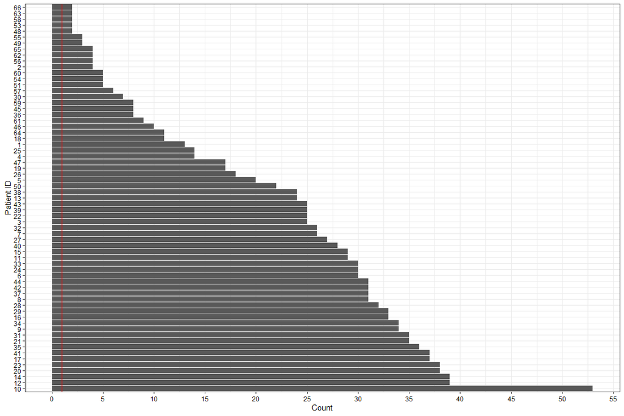

Identificar pacientes que receberam transfusão simples ou RCE de emergência entre os procedimentos. Em um primeiro momento, não vamos exclui-los, vamos somente quantificar quantos pacientes preenchem este critério e quantos procedimentos estão associados com essas transfusões simples/RCE de emergência.

Patient n = 21

| patient_id | simple_rbc_transfusion_since_previous_rce | urgent_emergent_rce_since_previous_rce |
| --- | --- | --- |
| 1 | Yes | No |
| 2 | Yes | No |
| 2 | Yes | No |
| 5 | Yes | No |
| 5 | Yes | No |
| 6 | Yes | No |
| 13 | Yes | No |
| 19 | Yes | No |
| 21 | Yes | No |
| 26 | Yes | No |
| 27 | Yes | No |
| 30 | Yes | No |
| 33 | Yes | No |
| 35 | Yes | No |
| 36 | Yes | No |
| 36 | Yes | No |
| 38 | Yes | No |
| 39 | Yes | No |
| 39 | Yes | No |
| 39 | Yes | No |
| 40 | Yes | No |
| 50 | Yes | No |
| 51 | Yes | No |
| 54 | Yes | No |
| 57 | Yes | No |
| 62 | Yes | No |

Identificar o numero de pacientes que desenvolveram novos anticorpos ao longo dos procedimentos.

Patient n = 10

| patient_id | pre_rce_type_screen_new_rbc_alloantibodies | if_yes_select_all_that_apply |
| --- | --- | --- |
| 6 | Yes | anti-V |
| 8 | Yes | anti-V, anti-VS |
| 13 | Yes | 1/5/22: Warm autoantibody |
| 13 | Yes | 5/17/22: Warm autoantibody |
| 21 | Yes | 9/25/20: Warm autoantibody |
| 21 | Yes | 12/23/20: Anti-Dia |
| 23 | Yes | 5/28/20: Anti-Jsa |
| 31 | Yes | 10/30/20: Low Frequency Aby |
| 42 | Yes | 8/17/20: Direct Coombs Anti-IgG |
| 42 | Yes | 10/26/20: Warm Autoantibody |
| 45 | Yes | 1/20/22: Anti-C, Anti-K, Non-specific Aby, Warm Autoantibody |
| 47 | Yes | 10/5/22: Anti-Kpa |
| 62 | Yes | 11/8/22: Anti-K |

# Descriptive Statistic

## Study Cohort Characterics

### Total

| Characteristic | N = 65 |
| --- | --- |
| Age |  |
| Mean (SD) | 30 (13) |
| Median | 26 |
| Min - Max | 8 - 70 |
| Q1 - Q3 | 21 - 38 |
| Height (cm) |  |
| Mean (SD) | 167 (13) |
| Median | 165 |
| Min - Max | 130 - 197 |
| Q1 - Q3 | 160 - 175 |
| Weight (kg) |  |
| Mean (SD) | 68 (20) |
| Median | 67 |
| Min - Max | 25 - 124 |
| Q1 - Q3 | 59 - 79 |

| Characteristic | N = 651 |
| --- | --- |
| Gender |  |
| Female | 33.0 (50.8%) |
| Male | 32.0 (49.2%) |
| Race |  |
| Black | 61.0 (93.8%) |
| other | 3.0 (4.6%) |
| White | 1.0 (1.5%) |
| SCD Genotype (New) |  |
| Group 1 - SS/SBO thal | 59.0 (90.8%) |
| Group 2 - SC/sickle cell beta plus thalassemia | 4.0 (6.2%) |
| Other | 2.0 (3.1%) |
| Splenectomy (%) |  |
| No | 53.0 (81.5%) |
| Yes | 12.0 (18.5%) |
| Splenomegaly or Hepatomegaly (%) |  |
| No | 47.0 (72.3%) |
| Y (liver) | 2.0 (3.1%) |
| Yes | 14.0 (21.5%) |
| Yes (liver) | 1.0 (1.5%) |
| Yes (spleen) | 1.0 (1.5%) |
| ABO Group |  |
| G:A - D pos | 10.0 (15.4%) |
| G:AB - D pos | 5.0 (7.7%) |
| G:B - D pos | 12.0 (18.5%) |
| G:O - D neg | 2.0 (3.1%) |
| G:O - D pos | 36.0 (55.4%) |

1n (%)

### Stratified Yes-RBC antibodies vs. No-RBC antibodies

| RBC antibodies | No N = 36 | Yes N = 29 | p-value1 |
| --- | --- | --- | --- |
| Age |  |  | 0.78 |
| Mean (SD) | 30 (14) | 29 (12) |  |
| Median | 26 | 28 |  |
| Min - Max | 8 - 70 | 8 - 61 |  |
| Q1 - Q3 | 22 - 39 | 21 - 37 |  |
| Height (cm) |  |  | 0.62 |
| Mean (SD) | 167 (14) | 166 (11) |  |
| Median | 166 | 165 |  |
| Min - Max | 134 - 197 | 130 - 183 |  |
| Q1 - Q3 | 159 - 178 | 162 - 173 |  |
| Weight (kg) |  |  | 0.93 |
| Mean (SD) | 69 (20) | 68 (19) |  |
| Median | 66 | 67 |  |
| Min - Max | 26 - 120 | 25 - 124 |  |
| Q1 - Q3 | 60 - 79 | 58 - 79 |  |

1Wilcoxon rank sum test

| RBC antibodies | No N = 361 | Yes N = 291 | p-value2 |
| --- | --- | --- | --- |
| Gender |  |  | >0.99 |
| Female | 18.0 (50.0%) | 15.0 (51.7%) |  |
| Male | 18.0 (50.0%) | 14.0 (48.3%) |  |
| Race |  |  | 0.77 |
| Black | 34.0 (94.4%) | 27.0 (93.1%) |  |
| other | 1.0 (2.8%) | 2.0 (6.9%) |  |
| White | 1.0 (2.8%) | 0.0 (0.0%) |  |
| SCD Genotype |  |  | >0.99 |
| Group 1 - SS/SBO thal | 33.0 (91.7%) | 26.0 (89.7%) |  |
| Group 2 - SC/sickle cell beta plus thalassemia | 2.0 (5.6%) | 2.0 (6.9%) |  |
| Other | 1.0 (2.8%) | 1.0 (3.4%) |  |
| Splenectomy (%) |  |  | >0.99 |
| No | 29.0 (80.6%) | 24.0 (82.8%) |  |
| Yes | 7.0 (19.4%) | 5.0 (17.2%) |  |
| Splenomegaly or Hepatomegaly (%) |  |  | 0.17 |
| No | 23.0 (63.9%) | 24.0 (82.8%) |  |
| Y (liver) | 2.0 (5.6%) | 0.0 (0.0%) |  |
| Yes | 10.0 (27.8%) | 4.0 (13.8%) |  |
| Yes (liver) | 0.0 (0.0%) | 1.0 (3.4%) |  |
| Yes (spleen) | 1.0 (2.8%) | 0.0 (0.0%) |  |
| ABO Group |  |  | >0.99 |
| G:A - D pos | 5.0 (13.9%) | 5.0 (17.2%) |  |
| G:AB - D pos | 3.0 (8.3%) | 2.0 (6.9%) |  |
| G:B - D pos | 7.0 (19.4%) | 5.0 (17.2%) |  |
| G:O - D neg | 1.0 (2.8%) | 1.0 (3.4%) |  |
| G:O - D pos | 20.0 (55.6%) | 16.0 (55.2%) |  |

1n (%)  
2Fisher's exact test

## ED Coding analysis

| Characteristic | N = 65 |
| --- | --- |
| # ED visits |  |
| Mean (SD) | 9 (14) |
| Median | 4 |
| Min - Max | 1 - 67 |
| Q1 - Q3 | 2 - 8 |
| Unknown | 15 |

| RBC antibodies | No N = 36 | Yes N = 29 | p-value1 |
| --- | --- | --- | --- |
| # ED visits |  |  | 0.75 |
| Mean (SD) | 9 (12) | 10 (17) |  |
| Median | 4 | 5 |  |
| Min - Max | 1 - 59 | 1 - 67 |  |
| Q1 - Q3 | 2 - 8 | 2 - 9 |  |
| Unknown | 5 | 10 |  |

1Wilcoxon rank sum test

## Hospital Admissions Coding analysis

| Characteristic | N = 65 |
| --- | --- |
| # Hospitalizations |  |
| Mean (SD) | 6 (7) |
| Median | 3 |
| Min - Max | 1 - 39 |
| Q1 - Q3 | 1 - 7 |
| Unknown | 14 |

| RBC antibodies | No N = 36 | Yes N = 29 | p-value1 |
| --- | --- | --- | --- |
| # Hospitalizations |  |  | 0.57 |
| Mean (SD) | 6 (5) | 6 (9) |  |
| Median | 4 | 3 |  |
| Min - Max | 1 - 25 | 1 - 39 |  |
| Q1 - Q3 | 2 - 8 | 1 - 6 |  |
| Unknown | 6 | 8 |  |

1Wilcoxon rank sum test

# Coorte do estudo

- Excluindo o paciente 52;
- Excluindo procedimentos que tiveram Transfusão simples de hemácias desde RCE anterior ( *Simple RBC Transfusion Since Previous RCE?* );

| Patient ID | Date of RCE | Simple RBC Transfusion Since Previous RCE? |
| --- | --- | --- |
| 1 | 2021-12-10 | Yes |
| 2 | 2020-05-01 | Yes |
| 2 | 2020-09-29 | Yes |
| 3 | 2020-01-28 |  |
| 5 | 2020-02-14 | Yes |
| 5 | 2022-06-18 | Yes |
| 5 | 2022-12-05 |  |
| 6 | 2020-08-20 | Yes |
| 9 | 2020-02-05 |  |
| 13 | 2020-05-18 | Yes |
| 18 | 2020-10-07 |  |
| 18 | 2022-08-24 |  |
| 19 | 2021-05-12 | Yes |
| 21 | 2020-05-15 | Yes |
| 26 | 2020-05-07 | Yes |
| 27 | 2020-05-07 | Yes |
| 30 | 2020-12-10 | Yes |
| 33 | 2020-05-05 | Yes |
| 35 | 2020-07-27 | Yes |
| 36 | 2020-11-25 | Yes |
| 36 | 2021-05-12 | Yes |
| 38 | 2020-05-18 | Yes |
| 39 | 2020-05-22 | Yes |
| 39 | 2021-07-09 | Yes |
| 39 | 2022-05-03 | Yes |
| 40 | 2020-05-06 | Yes |
| 46 | 2021-09-16 |  |
| 50 | 2020-01-10 |  |
| 50 | 2021-05-17 | Yes |
| 51 | 2022-05-16 | Yes |
| 54 | 2021-01-06 | Yes |
| 57 | 2022-09-20 | Yes |
| 62 | 2022-09-07 | Yes |

Temos 65 pacientes, e 1.307 procedimentos

Frequência dos procedimentos pelos 65 pacientes - Totalizando 1307 procedimentos (sem filtro de Delta Hba)

| patient_id | n |
| --- | --- |
| 10 | 53 |
| 12 | 39 |
| 14 | 39 |
| 20 | 38 |
| 23 | 38 |
| 17 | 37 |
| 41 | 37 |
| 31 | 35 |
| 35 | 35 |
| 21 | 34 |
| 34 | 34 |
| 9 | 33 |
| 16 | 33 |
| 29 | 33 |
| 28 | 32 |
| 8 | 31 |
| 37 | 31 |
| 42 | 31 |
| 44 | 31 |
| 24 | 30 |
| 6 | 29 |
| 11 | 29 |
| 15 | 29 |
| 33 | 29 |
| 40 | 27 |
| 7 | 26 |
| 27 | 26 |
| 32 | 26 |
| 22 | 25 |
| 43 | 25 |
| 3 | 24 |
| 13 | 23 |
| 38 | 23 |
| 39 | 22 |
| 50 | 20 |
| 5 | 17 |
| 26 | 17 |
| 47 | 17 |
| 19 | 16 |
| 4 | 14 |
| 25 | 14 |
| 1 | 12 |
| 64 | 11 |
| 18 | 9 |
| 46 | 9 |
| 61 | 9 |
| 45 | 8 |
| 59 | 8 |
| 30 | 6 |
| 36 | 6 |
| 57 | 5 |
| 60 | 5 |
| 51 | 4 |
| 54 | 4 |
| 56 | 4 |
| 65 | 4 |
| 49 | 3 |
| 55 | 3 |
| 62 | 3 |
| 2 | 2 |
| 48 | 2 |
| 53 | 2 |
| 58 | 2 |
| 63 | 2 |
| 66 | 2 |

# Análises considerando DeltaHbA (%)

Casos que foram excluidos pois não apresentagem valores para preHbA (Coluna AC) e/ou posHbA (Coluna AM)

Tabela de procedimentos sem mensuração na coluna de preHbA ou posHba

| patient_id | date_of_rce | pre_a_percent | post_a_percent |
| --- | --- | --- | --- |
| 3 | 2021-12-09 | 67.3 | not assessed |
| 8 | 2020-01-17 | 45.3 | not assessed |
| 8 | 2020-10-30 | 56.2 | not assessed |
| 8 | 2021-12-09 | 53 | Not assessed |
| 16 | 2020-04-23 | 49 | N/A |
| 17 | 2022-01-21 | not assessed | 89.8 |
| 19 | 2021-12-27 | not assessed | 83.4 |
| 22 | 2020-10-22 | not assessed | 76.4 |
| 23 | 2020-07-23 | 81.6 | not assessed |
| 23 | 2022-02-10 | not assessed | 79.2 |
| 30 | 2020-10-08 | not assessed | 76.5 |
| 39 | 2022-05-25 | not assessed | 81.4 |
| 41 | 2022-07-25 | 55.2 | not assessed |

Número total de procedimentos RCE presentes em nossa corte que possuem ambos o preHbA e posHbA mensurados

Tabela descritiva para Diferença entre da data de procedimentos

| Characteristic | N = 1,294 |
| --- | --- |
| DIFF_Between_RCE |  |
| Mean (SD) | 37 (29) |
| Min \| Median \| Max | 4 \| 29 \| 547 |
| Unknown | 65 |

Frequência dos procedimentos pelos 65 pacientes - Totalizando 1294 procedimentos (com filtro de Delta HbA Porcentagem)

| patient_id | n |
| --- | --- |
| 10 | 53 |
| 12 | 39 |
| 14 | 39 |
| 20 | 38 |
| 17 | 36 |
| 23 | 36 |
| 41 | 36 |
| 31 | 35 |
| 35 | 35 |
| 21 | 34 |
| 34 | 34 |
| 9 | 33 |
| 29 | 33 |
| 16 | 32 |
| 28 | 32 |
| 37 | 31 |
| 42 | 31 |
| 44 | 31 |
| 24 | 30 |
| 6 | 29 |
| 11 | 29 |
| 15 | 29 |
| 33 | 29 |
| 8 | 28 |
| 40 | 27 |
| 7 | 26 |
| 27 | 26 |
| 32 | 26 |
| 43 | 25 |
| 22 | 24 |
| 3 | 23 |
| 13 | 23 |
| 38 | 23 |
| 39 | 21 |
| 50 | 20 |
| 5 | 17 |
| 26 | 17 |
| 47 | 17 |
| 19 | 15 |
| 4 | 14 |
| 25 | 14 |
| 1 | 12 |
| 64 | 11 |
| 18 | 9 |
| 46 | 9 |
| 61 | 9 |
| 45 | 8 |
| 59 | 8 |
| 36 | 6 |
| 30 | 5 |
| 57 | 5 |
| 60 | 5 |
| 51 | 4 |
| 54 | 4 |
| 56 | 4 |
| 65 | 4 |
| 49 | 3 |
| 55 | 3 |
| 62 | 3 |
| 2 | 2 |
| 48 | 2 |
| 53 | 2 |
| 58 | 2 |
| 63 | 2 |
| 66 | 2 |

Tamanho da coorte filtando os procedimentos que não possuiam valores de preHbA (Coluna AC) e/ou posHbA (Coluna AM). Para os 65 pacientes com a quantidade de 1294 procedimentos.

Boxplot ordenado pela mediana

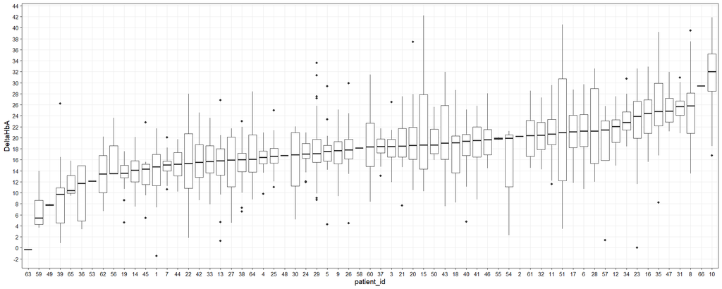

Boxplot ordenado pela variância

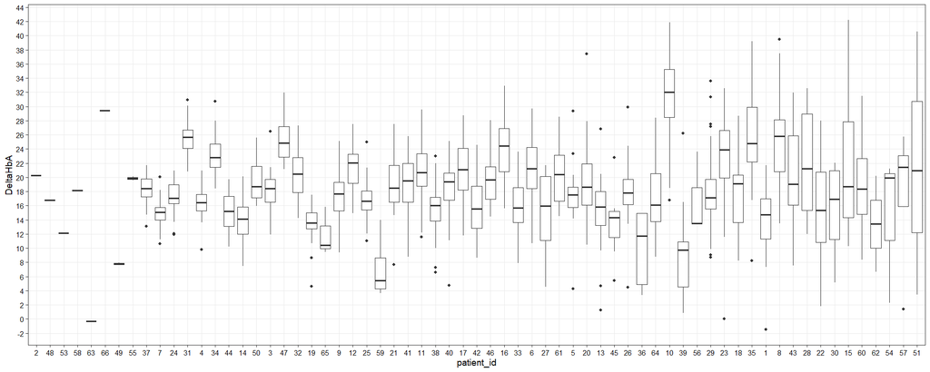

## Identificando o valor de Delta HbA para aqueles que apresentam aloanticorpos para hemácia

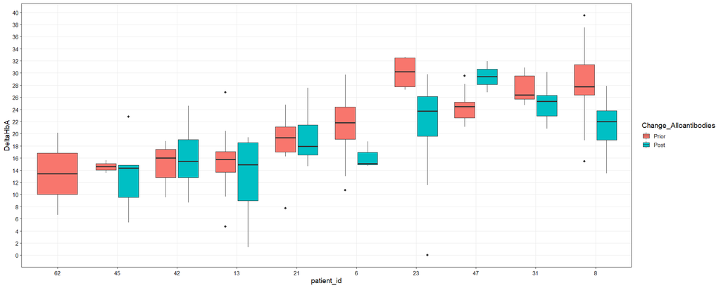

## Análise para rbc_antibodies (RBC Autoantibodies)

## Estatística Total

```
##                                Names                        Code_Names
## 1       Goal/Target Post-RCE HCT (%)  goal_target_post_rce_hct_percent
## 2     Goal/Target Post-RCE HbS   (%) goal_target_post_rce_hb_s_percent
## 3                  Pre-RCE Hb (g/dL)                  pre_rce_hb_g_d_l
## 4                            Pre A %                     pre_a_percent
## 5                    Pre-RCE HbS (%)              pre_rce_hb_s_percent
## 6                 Post-RCE Hb (g/dL)                 post_rce_hb_g_d_l
## 7                           Post A %                    post_a_percent
## 8                   Post-RCE HbS (%)             post_rce_hb_s_percent
## 9 difference between procedure times                  DIFF_Between_RCE
```

| Characteristic | N = 1,294 |
| --- | --- |
| Goal/Target Post-RCE HCT (%) |  |
| Mean (SD) | 29.3 (2.9) |
| Median | 30.0 |
| Min - Max | 20.0 - 39.0 |
| Q1 - Q3 | 28.0 - 30.0 |
| Unknown | 1 |
| Goal/Target Post-RCE HbS (%) |  |
| Mean (SD) | 20.6 (7.6) |
| Median | 20.0 |
| Min - Max | 10.0 - 70.0 |
| Q1 - Q3 | 15.0 - 25.0 |
| Unknown | 3 |
| Pre-RCE Hb (g/dL) |  |
| Mean (SD) | 9.28 (1.41) |
| Median | 9.40 |
| Min - Max | 4.10 - 13.10 |
| Q1 - Q3 | 8.50 - 10.20 |
| Unknown | 2 |
| Pre-RCE HbS (%) |  |
| Mean (SD) | 40 (13) |
| Median | 39 |
| Min - Max | 0 - 94 |
| Q1 - Q3 | 32 - 46 |
| Unknown | 2 |
| Pre A % |  |
| Mean (SD) | 56 (13) |
| Median | 58 |
| Min - Max | 3 - 88 |
| Q1 - Q3 | 51 - 64 |
| Post-RCE Hb (g/dL) |  |
| Mean (SD) | 9.93 (1.11) |
| Median | 10.00 |
| Min - Max | 6.50 - 13.60 |
| Q1 - Q3 | 9.30 - 10.70 |
| Unknown | 3 |
| Post-RCE HbS (%) |  |
| Mean (SD) | 17 (7) |
| Median | 15 |
| Min - Max | 4 - 48 |
| Q1 - Q3 | 13 - 21 |
| Unknown | 1 |
| Post A % |  |
| Mean (SD) | 80 (8) |
| Median | 82 |
| Min - Max | 3 - 95 |
| Q1 - Q3 | 76 - 86 |
| DIFF_Between_RCE |  |
| Mean (SD) | 37 (29) |
| Median | 29 |
| Min - Max | 4 - 547 |
| Q1 - Q3 | 28 - 36 |
| Unknown | 65 |

## Comparação por RBC Antibodies

| Names | Code_Names | Estimation.mean.least.rbc_antibodies | Estimation.mean.least.emmean | Estimation.mean.least.SE | p.value |
| --- | --- | --- | --- | --- | --- |
| Goal/Target Post-RCE HCT (%) | goal_target_post_rce_hct_percent | No | 28.81523 | 0.4584225 | 0.3240271 |
|  |  | Yes | 28.13361 | 0.5099635 |  |

| Names | Code_Names | Estimation.mean.least.rbc_antibodies | Estimation.mean.least.emmean | Estimation.mean.least.SE | p.value |
| --- | --- | --- | --- | --- | --- |
| Goal/Target Post-RCE HbS (%) | goal_target_post_rce_hb_s_percent | No | 22.22174 | 1.170106 | 0.7251137 |
|  |  | Yes | 22.84002 | 1.301999 |  |

| Names | Code_Names | Estimation.mean.least.rbc_antibodies | Estimation.mean.least.emmean | Estimation.mean.least.SE | p.value |
| --- | --- | --- | --- | --- | --- |
| Pre-RCE Hb (g/dL) | pre_rce_hb_g_d_l | No | 9.002612 | 0.2225633 | 0.9073243 |
|  |  | Yes | 9.041535 | 0.2477105 |  |

| Names | Code_Names | Estimation.mean.least.rbc_antibodies | Estimation.mean.least.emmean | Estimation.mean.least.SE | p.value |
| --- | --- | --- | --- | --- | --- |
| Pre-RCE HbS (%) | pre_rce_hb_s_percent | No | 44.35637 | 1.951462 | 0.5190184 |
|  |  | Yes | 42.46498 | 2.165630 |  |

| Names | Code_Names | Estimation.mean.least.rbc_antibodies | Estimation.mean.least.emmean | Estimation.mean.least.SE | p.value |
| --- | --- | --- | --- | --- | --- |
| Pre A % | pre_a_percent | No | 49.87685 | 2.342540 | 0.5869188 |
|  |  | Yes | 51.79012 | 2.602215 |  |

| Names | Code_Names | Estimation.mean.least.rbc_antibodies | Estimation.mean.least.emmean | Estimation.mean.least.SE | p.value |
| --- | --- | --- | --- | --- | --- |
| Post-RCE Hb (g/dL) | post_rce_hb_g_d_l | No | 9.742047 | 0.1618994 | 0.915452 |
|  |  | Yes | 9.716251 | 0.1798998 |  |

| Names | Code_Names | Estimation.mean.least.rbc_antibodies | Estimation.mean.least.emmean | Estimation.mean.least.SE | p.value |
| --- | --- | --- | --- | --- | --- |
| Post-RCE HbS (%) | post_rce_hb_s_percent | No | 20.12886 | 0.9974843 | 0.05284269 |
|  |  | Yes | 17.18468 | 1.1078476 |  |

| Names | Code_Names | Estimation.mean.least.rbc_antibodies | Estimation.mean.least.emmean | Estimation.mean.least.SE | p.value |
| --- | --- | --- | --- | --- | --- |
| Post A % | post_a_percent | No | 76.74432 | 1.866926 | 0.7356903 |
|  |  | Yes | 77.69183 | 2.077872 |  |

| Names | Code_Names | Estimation.mean.least.rbc_antibodies | Estimation.mean.least.emmean | Estimation.mean.least.SE | p.value |
| --- | --- | --- | --- | --- | --- |
| difference between procedure times | DIFF_Between_RCE | No | 52.03868 | 6.153136 | 0.4926735 |
|  |  | Yes | 45.68340 | 6.841105 |  |

## Nomograma

| Characteristic | N = 1,2941 |
| --- | --- |
| dhtr_likelihood_nomogram_results |  |
| High | 7 (0.6%) |
| Intermediate | 24 (2.1%) |
| Low | 1,119 (97%) |
| Unknown | 144 |

1n (%)

| Characteristic | No N = 6631 | Yes N = 6311 | p-value2 |
| --- | --- | --- | --- |
| dhtr_likelihood_nomogram_results |  |  | 0.071 |
| High | 6 (1.0%) | 1 (0.2%) |  |
| Intermediate | 15 (2.6%) | 9 (1.6%) |  |
| Low | 556 (96%) | 563 (98%) |  |
| Unknown | 86 | 58 |  |

1n (%)  
2Fisher's exact test

## Planilha **DataAdditional**

### Age Unit

Juntando a coorte com a planilha de *Age Unit* e excluindo os casos que não possuem procedimentos pré ou pos

| Characteristic | N = 65 |
| --- | --- |
| Mean Age of Unit by Patient |  |
| Mean (SD) | 17.5 (3.8) |
| Median | 17.6 |
| Min - Max | 8.2 - 27.4 |
| Q1 - Q3 | 15.0 - 19.7 |

| RBC antibodies | No N = 36 | Yes N = 29 | p-value1 |
| --- | --- | --- | --- |
| Mean Age of Unit by Patient |  |  | 0.94 |
| Mean (SD) | 17.3 (3.3) | 17.7 (4.4) |  |
| Median | 18.2 | 16.5 |  |
| Min - Max | 11.3 - 23.9 | 8.2 - 27.4 |  |
| Q1 - Q3 | 14.6 - 19.7 | 15.3 - 19.8 |  |

1Wilcoxon rank sum exact test

### ED Coding

| Characteristic | N = 65 |
| --- | --- |
| Count ED Coding by Patient |  |
| Mean (SD) | 6 (12) |
| Median | 2 |
| Min - Max | 0 - 59 |
| Q1 - Q3 | 0 - 6 |

| RBC antibodies | No N = 36 | Yes N = 29 | p-value1 |
| --- | --- | --- | --- |
| Count ED Coding by Patient |  |  | 0.20 |
| Mean (SD) | 6 (11) | 6 (13) |  |
| Median | 3 | 1 |  |
| Min - Max | 0 - 59 | 0 - 52 |  |
| Q1 - Q3 | 1 - 6 | 0 - 5 |  |

1Wilcoxon rank sum test

### Hospital Admission

Organizando o banco

| Characteristic | N = 65 |
| --- | --- |
| Count Hospital Admission by Patient |  |
| Mean (SD) | 4 (6) |
| Median | 1 |
| Min - Max | 0 - 31 |
| Q1 - Q3 | 1 - 4 |

| RBC antibodies | No N = 36 | Yes N = 29 | p-value1 |
| --- | --- | --- | --- |
| Count Hospital Admission by Patient |  |  | 0.42 |
| Mean (SD) | 3 (5) | 4 (7) |  |
| Median | 2 | 1 |  |
| Min - Max | 0 - 25 | 0 - 31 |  |
| Q1 - Q3 | 1 - 4 | 0 - 4 |  |

1Wilcoxon rank sum test

## Modelos Linear para DeltaHbA (%)

| patient_id | date_of_rce | DeltaHbA_Porc | post_a_percent | pre_a_percent | DIFF_Between_RCE |
| --- | --- | --- | --- | --- | --- |
| 1 | 2020-10-16 | 16.675556 | 68.3 | 29.9 |  |
| 1 | 2022-11-02 |  | 64.0 | 37.4 | 36 |
| 2 | 2020-11-04 | 20.275862 | 65.2 | 47.5 |  |
| 2 | 2020-12-03 |  | 69.1 | 44.2 | 29 |
| 3 | 2020-03-09 | 19.786667 | 88.3 | 58.9 |  |
| 3 | 2022-08-18 |  | 83.7 | 58.8 | 38 |
| 4 | 2020-08-12 | 13.638710 | 74.8 | 4.0 |  |
| 4 | 2022-09-26 |  | 67.0 | 26.4 | 95 |
| 5 | 2020-04-03 | 17.097872 | 75.4 | 56.8 |  |
| 5 | 2022-10-20 |  | 79.1 | 47.1 | 42 |
| 6 | 2020-09-17 | 21.855556 | 85.8 | 60.3 |  |
| 6 | 2022-11-22 |  | 85.2 | 70.6 | 20 |
| 7 | 2020-01-21 | 16.253659 | 81.1 | 57.9 |  |
| 7 | 2022-12-12 |  | 82.8 | 56.6 | 42 |
| 8 | 2020-02-26 | 27.725490 | 82.3 | 40.5 |  |
| 8 | 2022-12-12 |  | 87.3 | 47.0 | 33 |
| 9 | 2020-03-05 | 11.415385 | 81.1 | 59.5 |  |
| 9 | 2022-12-08 |  | 85.5 | 65.0 | 27 |
| 10 | 2020-01-02 | 26.981818 | 77.4 | 57.9 |  |
| 10 | 2022-12-29 |  | 84.8 | 57.1 | 20 |
| 11 | 2020-01-24 | 23.280000 | 79.5 | 63.9 |  |
| 11 | 2022-11-29 |  | 77.1 | 63.8 | 39 |
| 12 | 2020-01-15 | 22.400000 | 87.4 | 62.6 |  |
| 12 | 2022-12-16 |  | 81.5 | 64.6 | 30 |
| 13 | 2020-06-15 | 15.837500 | 83.4 | 73.7 |  |
| 13 | 2022-11-21 |  | 84.5 | 51.3 | 87 |
| 14 | 2020-01-10 | 12.600000 | 76.9 | 60.1 |  |
| 14 | 2022-12-30 |  | 80.8 | 67.5 | 28 |
| 15 | 2020-01-10 | 11.900000 | 83.1 | 63.9 |  |
| 15 | 2022-12-12 |  | 84.5 | 71.5 | 24 |

[output cut: 100 more lines]

## Variabilidade intrapatient do deltaHbA

Análise descritiva dos valores de variância para Delta HBA (%)

## Modelos de Regressão Linear Simples - Comparação de DeltaHbA (%) para em relação as variáveis por paciente

Modelo de regressão linear simples

| Covariables | N | Beta | 95% CI | p-value |
| --- | --- | --- | --- | --- |
| age_years_2 | 65 | -0.07 | -0.17, 0.03 | 0.2 |
| height_cm_5 | 65 | -0.01 | -0.11, 0.09 | 0.8 |
| weight_kg_6 | 65 | -0.04 | -0.10, 0.03 | 0.3 |
| sex_3 | 65 |  |  |  |
| Female |  | — | — |  |
| Male |  | 0.72 | -1.8, 3.3 | 0.6 |
| race_4 | 65 |  |  |  |
| Black |  | — | — |  |
| other |  | 1.3 | -4.8, 7.5 | 0.7 |
| White |  | 0.51 | -10, 11 | >0.9 |
| scd_genotype_7_RECAT | 65 |  |  |  |
| Group 1 - SS/SBO thal |  | — | — |  |
| Group 2 - SC/sickle cell beta plus thalassemia |  | 2.8 | -2.2, 7.8 | 0.3 |
| Other |  | -10 | -17, -3.0 | 0.006 |
| h_o_surgical_splenectomy | 65 |  |  |  |
| No |  | — | — |  |
| Yes |  | -0.19 | -3.5, 3.1 | >0.9 |
| h_o_hepatomegaly_splenomegaly | 65 |  |  |  |
| No |  | — | — |  |
| Yes |  | -1.6 | -4.4, 1.3 | 0.3 |
| rbc_antibodies | 65 |  |  |  |
| No |  | — | — |  |
| Yes |  | 0.16 | -2.4, 2.7 | 0.9 |
| ABO_Groups_D | 65 |  |  |  |
| G:A - D pos |  | — | — |  |
| G:AB - D pos |  | -1.6 | -7.4, 4.1 | 0.6 |
| G:B - D pos |  | -1.3 | -5.8, 3.3 | 0.6 |
| G:O - D neg |  | 1.1 | -7.0, 9.3 | 0.8 |
| G:O - D pos |  | -0.48 | -4.3, 3.3 | 0.8 |

Abbreviation: CI = Confidence Interval

## Modelos de Regressão Linear Mista - Comparação de DeltaHbA (%) para em relação as variáveis por paciente

| Covariables | Beta | 95% CI | p-value |
| --- | --- | --- | --- |
| pre_a_percent | -0.06 | -0.09, -0.03 | <0.001 |

Abbreviation: CI = Confidence Interval

| Covariables | Beta | 95% CI | p-value |
| --- | --- | --- | --- |
| post_a_percent | 0.15 | 0.10, 0.21 | <0.001 |

Abbreviation: CI = Confidence Interval

| Covariables | Beta | 95% CI | p-value |
| --- | --- | --- | --- |
| goal_target_post_rce_hct_percent | -0.75 | -0.93, -0.57 | <0.001 |

Abbreviation: CI = Confidence Interval

| Covariables | Beta | 95% CI | p-value |
| --- | --- | --- | --- |
| goal_target_post_rce_hb_s_percent | -0.10 | -0.20, 0.00 | 0.043 |

Abbreviation: CI = Confidence Interval

| Covariables | Beta | 95% CI | p-value |
| --- | --- | --- | --- |
| pre_rce_hb_s_percent | 0.08 | 0.05, 0.11 | <0.001 |

Abbreviation: CI = Confidence Interval

| Covariables | Beta | 95% CI | p-value |
| --- | --- | --- | --- |
| pre_rce_type_screen_new_rbc_alloantibodies |  |  |  |
| No | — | — |  |
| Yes | -0.17 | -3.0, 2.7 | >0.9 |

Abbreviation: CI = Confidence Interval

| Covariables | Beta | 95% CI | p-value |
| --- | --- | --- | --- |
| post_rce_hb_s_percent | -0.16 | -0.22, -0.09 | <0.001 |

Abbreviation: CI = Confidence Interval

| Covariables | Beta | 95% CI | p-value |
| --- | --- | --- | --- |
| dhtr_likelihood_nomogram_results |  |  |  |
| Low | — | — |  |
| High | 2.9 | -0.74, 6.5 | 0.12 |
| Intermediate | -1.5 | -3.5, 0.47 | 0.13 |

Abbreviation: CI = Confidence Interval

| Covariables | Beta | 95% CI | p-value |
| --- | --- | --- | --- |
| mean_age_unit | 0.04 | 0.00, 0.08 | 0.046 |

Abbreviation: CI = Confidence Interval

| Covariables | Beta | 95% CI | p-value |
| --- | --- | --- | --- |
| class_age_unit |  |  |  |
| minor 12 days | — | — |  |
| between 12 and 34 days | 0.07 | -0.59, 0.74 | 0.8 |
| more 34 days | 1.1 | -0.96, 3.3 | 0.3 |

Abbreviation: CI = Confidence Interval

| Covariables | Beta | 95% CI | p-value |
| --- | --- | --- | --- |
| pre_rce_type_screen_new_rbc_alloantibodies |  |  |  |
| No | — | — |  |
| Yes | -0.17 | -3.0, 2.7 | >0.9 |

Abbreviation: CI = Confidence Interval

| Covariables | Beta | 95% CI | p-value |
| --- | --- | --- | --- |
| received_a_c_trait_unit |  |  |  |
| No | — | — |  |
| Yes | 0.73 | -0.53, 2.0 | 0.3 |

Abbreviation: CI = Confidence Interval

| Covariables | Beta | 95% CI | p-value |
| --- | --- | --- | --- |
| DIFF_Between_RCE | 0.01 | 0.00, 0.02 | 0.2 |

Abbreviation: CI = Confidence Interval

## Modelo de Regressão Múltiplo

Regressão Linear Múltipla Mista

| Covariables | Beta | 95% CI | p-value |
| --- | --- | --- | --- |
| rbc_antibodies |  |  |  |
| No | — | — |  |
| Yes | -0.69 | -3.2, 1.8 | 0.6 |
| age_years_2 | -0.11 | -0.22, 0.00 | 0.042 |
| height_cm_5 | 0.03 | -0.11, 0.18 | 0.6 |
| weight_kg_6 | 0.02 | -0.07, 0.11 | 0.7 |
| sex_3 |  |  |  |
| Female | — | — |  |
| Male | 2.9 | -0.06, 5.8 | 0.054 |
| scd_genotype_7_RECAT |  |  |  |
| Group 1 - SS/SBO thal | — | — |  |
| Group 2 - SC/sickle cell beta plus thalassemia | 8.7 | 3.3, 14 | 0.002 |
| Other | -8.1 | -16, -0.48 | 0.038 |
| goal_target_post_rce_hct_percent | -0.74 | -0.91, -0.56 | <0.001 |
| goal_target_post_rce_hb_s_percent | -0.06 | -0.17, 0.05 | 0.3 |
| pre_rce_hb_s_percent | 0.13 | 0.09, 0.16 | <0.001 |
| post_rce_hb_s_percent | -0.23 | -0.30, -0.16 | <0.001 |
| dhtr_likelihood_nomogram_results |  |  |  |
| Low | — | — |  |
| High | 1.5 | -1.8, 4.9 | 0.4 |
| Intermediate | -1.2 | -3.1, 0.60 | 0.2 |
| mean_age_unit | 0.09 | 0.05, 0.13 | <0.001 |
| received_a_c_trait_unit |  |  |  |
| No | — | — |  |
| Yes | 0.33 | -0.83, 1.5 | 0.6 |

Abbreviation: CI = Confidence Interval

## Correlação entre DeltaHbA (%) x ED Coding e DeltaHbA (%) x Hospital Admission

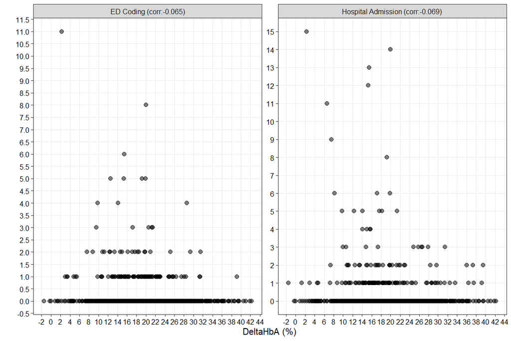

## Perfil de Grupos de Delta HBA (%) pela Mediana

Delta (%) $<$ 16.23 ~ Grupo 1 Delta (%) $\geq$ 16.23 & Delta (%) $<$ 19.59 ~ Grupo 2 Delta (%) $\geq$ 19.59 ~ Grupo 3

### 3 Grupos

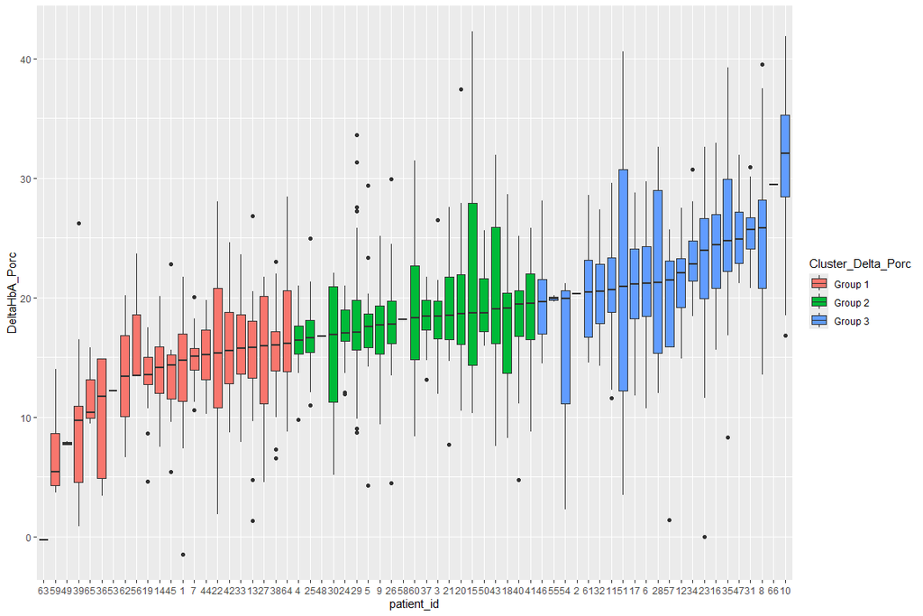

| Tercil with Delta gdL | Group 1 N = 221 | Group 2 N = 211 | Group 3 N = 221 | p-value2 |
| --- | --- | --- | --- | --- |
| RBC antibodies |  |  |  | 0.51 |
| No | 13 (59%) | 13 (62%) | 10 (45%) |  |
| Yes | 9 (41%) | 8 (38%) | 12 (55%) |  |
| Age |  |  |  | 0.039 |
| Mean (SD) | 35 (15) | 26 (13) | 29 (10) |  |
| Median | 38 | 22 | 26 |  |
| Min - Max | 8 - 61 | 11 - 70 | 11 - 51 |  |
| Q1 - Q3 | 26 - 44 | 18 - 34 | 22 - 36 |  |
| Height (cm) |  |  |  | 0.67 |
| Mean (SD) | 167 (16) | 167 (10) | 167 (11) |  |
| Median | 169 | 165 | 164 |  |
| Min - Max | 130 - 193 | 145 - 185 | 147 - 197 |  |
| Q1 - Q3 | 163 - 178 | 160 - 175 | 160 - 175 |  |
| Weight (kg) |  |  |  | 0.75 |
| Mean (SD) | 71 (25) | 67 (19) | 67 (13) |  |
| Median | 67 | 66 | 68 |  |
| Min - Max | 25 - 124 | 37 - 107 | 36 - 92 |  |
| Q1 - Q3 | 62 - 81 | 55 - 76 | 60 - 76 |  |
| Gender |  |  |  | 0.57 |
| Female | 11 (50%) | 9 (43%) | 13 (59%) |  |
| Male | 11 (50%) | 12 (57%) | 9 (41%) |  |
| Race |  |  |  | 0.17 |
| Black | 22 (100%) | 18 (86%) | 21 (95%) |  |
| other | 0 (0%) | 2 (9.5%) | 1 (4.5%) |  |
| White | 0 (0%) | 1 (4.8%) | 0 (0%) |  |
| SCD Genotype |  |  |  | 0.030 |
| Group 1 - SS/SBO thal | 21 (95%) | 20 (95%) | 18 (82%) |  |
| Group 2 - SC/sickle cell beta plus thalassemia | 0 (0%) | 0 (0%) | 4 (18%) |  |
| Other | 1 (4.5%) | 1 (4.8%) | 0 (0%) |  |
| Splenectomy (%) |  |  |  | 0.25 |
| No | 18 (82%) | 15 (71%) | 20 (91%) |  |
| Yes | 4 (18%) | 6 (29%) | 2 (9.1%) |  |
| Splenomegaly or Hepatomegaly (%) |  |  |  | 0.15 |
| no | 13 (59%) | 18 (86%) | 16 (73%) |  |
| yes | 9 (41%) | 3 (14%) | 6 (27%) |  |
| abo_group_11 |  |  |  | 0.33 |
| A | 4 (18%) | 1 (4.8%) | 5 (23%) |  |
| AB | 2 (9.1%) | 2 (9.5%) | 1 (4.5%) |  |
| B | 3 (14%) | 7 (33%) | 2 (9.1%) |  |
| O | 13 (59%) | 11 (52%) | 14 (64%) |  |
| ABO Group |  |  |  | 0.39 |
| G:A - D pos | 4 (18%) | 1 (4.8%) | 5 (23%) |  |
| G:AB - D pos | 2 (9.1%) | 2 (9.5%) | 1 (4.5%) |  |
| G:B - D pos | 3 (14%) | 7 (33%) | 2 (9.1%) |  |
| G:O - D neg | 0 (0%) | 1 (4.8%) | 1 (4.5%) |  |
| G:O - D pos | 13 (59%) | 10 (48%) | 13 (59%) |  |

1n (%)  
2Pearson's Chi-squared test; Kruskal-Wallis rank sum test; Fisher's exact test

| RBC antibodies | Group 1 N = 22 | Group 2 N = 21 | Group 3 N = 22 | p-value1 |
| --- | --- | --- | --- | --- |
| Mean Age of Unit by Patient |  |  |  | >0.99 |
| Mean (SD) | 17.5 (4.4) | 17.5 (3.8) | 17.6 (3.3) |  |
| Median | 17.1 | 18.2 | 17.4 |  |
| Min - Max | 8.2 - 26.4 | 11.4 - 24.1 | 11.9 - 27.4 |  |
| Q1 - Q3 | 14.7 - 19.7 | 14.5 - 20.4 | 15.6 - 19.4 |  |

1Kruskal-Wallis rank sum test

| Characteristic | Group 1 N = 22 | Group 2 N = 21 | Group 3 N = 22 | p-value1 |
| --- | --- | --- | --- | --- |
| Count ED Coding by Patient |  |  |  | 0.53 |
| Mean (SD) | 6 (8) | 8 (17) | 5 (10) |  |
| Median | 3 | 2 | 1 |  |
| Min - Max | 0 - 30 | 0 - 59 | 0 - 45 |  |
| Q1 - Q3 | 1 - 6 | 0 - 5 | 0 - 5 |  |

1Kruskal-Wallis rank sum test

[1] “pre_a_percent”

| Names | Code_Names | Estimation.mean.least.Cluster_Delta_Porc | Estimation.mean.least.emmean | Estimation.mean.least.SE | p.value |
| --- | --- | --- | --- | --- | --- |
| Pre A % | pre_a_percent | Group 1 | 50.22232 | 3.116715 | 0.7645684 |
|  |  | Group 2 | 51.55642 | 3.150272 |  |
|  |  | Group 3 | 50.27720 | 3.096164 |  |

[1] “post_a_percent”

| Names | Code_Names | Estimation.mean.least.Cluster_Delta_Porc | Estimation.mean.least.emmean | Estimation.mean.least.SE | p.value |
| --- | --- | --- | --- | --- | --- |
| Post A % | post_a_percent | Group 1 | 74.23915 | 2.239653 | 0.116426 |
|  |  | Group 2 | 79.34119 | 2.278079 |  |
|  |  | Group 3 | 79.01627 | 2.232403 |  |

[1] “goal_target_post_rce_hct_percent”

| Names | Code_Names | Estimation.mean.least.Cluster_Delta_Porc | Estimation.mean.least.emmean | Estimation.mean.least.SE | p.value |
| --- | --- | --- | --- | --- | --- |
| Goal/Target Post-RCE HCT (%) | goal_target_post_rce_hct_percent | Group 1 | 27.31821 | 0.5705464 | 0.008147788 |
|  |  | Group 2 | 29.54439 | 0.5791502 |  |
|  |  | Group 3 | 28.65760 | 0.5680850 |  |

[1] “goal_target_post_rce_hb_s_percent”

| Names | Code_Names | Estimation.mean.least.Cluster_Delta_Porc | Estimation.mean.least.emmean | Estimation.mean.least.SE | p.value |
| --- | --- | --- | --- | --- | --- |
| Goal/Target Post-RCE HbS (%) | goal_target_post_rce_hb_s_percent | Group 1 | 25.35444 | 1.457748 | 0.05300356 |
|  |  | Group 2 | 21.19790 | 1.520853 |  |
|  |  | Group 3 | 20.80593 | 1.455249 |  |

[1] “pre_rce_hb_s_percent”

| Names | Code_Names | Estimation.mean.least.Cluster_Delta_Porc | Estimation.mean.least.emmean | Estimation.mean.least.SE | p.value |
| --- | --- | --- | --- | --- | --- |
| Pre-RCE HbS (%) | pre_rce_hb_s_percent | Group 1 | 43.85287 | 2.588681 | 0.9722562 |
|  |  | Group 2 | 43.98125 | 2.607813 |  |
|  |  | Group 3 | 42.93026 | 2.566875 |  |

[1] “post_rce_hb_s_percent”

| Names | Code_Names | Estimation.mean.least.Cluster_Delta_Porc | Estimation.mean.least.emmean | Estimation.mean.least.SE | p.value |
| --- | --- | --- | --- | --- | --- |
| Post-RCE HbS (%) | post_rce_hb_s_percent | Group 1 | 19.44491 | 1.296182 | 0.8534954 |
|  |  | Group 2 | 19.10349 | 1.307495 |  |
|  |  | Group 3 | 17.43166 | 1.286237 |  |

[1] “DIFF_Between_RCE”

| Names | Code_Names | Estimation.mean.least.Cluster_Delta_Porc | Estimation.mean.least.emmean | Estimation.mean.least.SE | p.value |
| --- | --- | --- | --- | --- | --- |
| difference between procedure times | DIFF_Between_RCE | Group 1 | 56.56843 | 8.109139 | 0.2821262 |
|  |  | Group 2 | 44.02455 | 8.181393 |  |
|  |  | Group 3 | 43.15913 | 8.047192 |  |

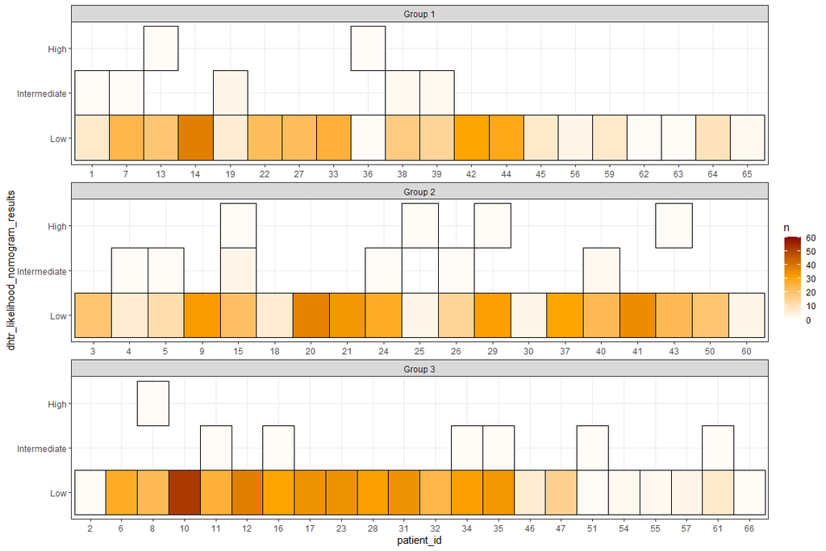

| Characteristic | Group 1 N = 3291 | Group 2 N = 4231 | Group 3 N = 4771 | p-value2 |
| --- | --- | --- | --- | --- |
| dhtr_likelihood_nomogram_results |  |  |  | 0.21 |
| Low | 285 (96%) | 377 (97%) | 456 (98%) |  |
| High | 2 (0.7%) | 4 (1.0%) | 1 (0.2%) |  |
| Intermediate | 9 (3.0%) | 9 (2.3%) | 6 (1.3%) |  |
| Unknown | 33 | 33 | 14 |  |

1n (%)  
2Fisher's Exact Test for Count Data with simulated p-value (based on 2000 replicates)

### 2 Grupos

| Tercil with Delta gdL | Group 1 N = 221 | Group 3 N = 221 | p-value2 |
| --- | --- | --- | --- |
| RBC antibodies |  |  | 0.37 |
| No | 13 (59%) | 10 (45%) |  |
| Yes | 9 (41%) | 12 (55%) |  |
| Age |  |  | 0.11 |
| Mean (SD) | 35 (15) | 29 (10) |  |
| Median | 38 | 26 |  |
| Min - Max | 8 - 61 | 11 - 51 |  |
| Q1 - Q3 | 26 - 44 | 22 - 36 |  |
| Height (cm) |  |  | 0.38 |
| Mean (SD) | 167 (16) | 167 (11) |  |
| Median | 169 | 164 |  |
| Min - Max | 130 - 193 | 147 - 197 |  |
| Q1 - Q3 | 163 - 178 | 160 - 175 |  |
| Weight (kg) |  |  | 0.56 |
| Mean (SD) | 71 (25) | 67 (13) |  |
| Median | 67 | 68 |  |
| Min - Max | 25 - 124 | 36 - 92 |  |
| Q1 - Q3 | 62 - 81 | 60 - 76 |  |
| Gender |  |  | 0.54 |
| Female | 11 (50%) | 13 (59%) |  |
| Male | 11 (50%) | 9 (41%) |  |
| Race |  |  | >0.99 |
| Black | 22 (100%) | 21 (95%) |  |
| other | 0 (0%) | 1 (4.5%) |  |
| SCD Genotype |  |  | 0.11 |
| Group 1 - SS/SBO thal | 21 (95%) | 18 (82%) |  |
| Group 2 - SC/sickle cell beta plus thalassemia | 0 (0%) | 4 (18%) |  |
| Other | 1 (4.5%) | 0 (0%) |  |
| Splenectomy (%) |  |  | 0.66 |
| No | 18 (82%) | 20 (91%) |  |
| Yes | 4 (18%) | 2 (9.1%) |  |
| Splenomegaly or Hepatomegaly (%) |  |  | 0.34 |
| no | 13 (59%) | 16 (73%) |  |
| yes | 9 (41%) | 6 (27%) |  |
| abo_group_11 |  |  | >0.99 |
| A | 4 (18%) | 5 (23%) |  |
| AB | 2 (9.1%) | 1 (4.5%) |  |
| B | 3 (14%) | 2 (9.1%) |  |
| O | 13 (59%) | 14 (64%) |  |
| ABO Group |  |  | >0.99 |
| G:A - D pos | 4 (18%) | 5 (23%) |  |
| G:AB - D pos | 2 (9.1%) | 1 (4.5%) |  |
| G:B - D pos | 3 (14%) | 2 (9.1%) |  |
| G:O - D neg | 0 (0%) | 1 (4.5%) |  |
| G:O - D pos | 13 (59%) | 13 (59%) |  |

1n (%)  
2Pearson's Chi-squared test; Wilcoxon rank sum test; Fisher's exact test

| RBC antibodies | Group 1 N = 22 | Group 3 N = 22 | p-value1 |
| --- | --- | --- | --- |
| Mean Age of Unit by Patient |  |  | 0.97 |
| Mean (SD) | 17.5 (4.4) | 17.6 (3.3) |  |
| Median | 17.1 | 17.4 |  |
| Min - Max | 8.2 - 26.4 | 11.9 - 27.4 |  |
| Q1 - Q3 | 14.7 - 19.7 | 15.6 - 19.4 |  |

1Wilcoxon rank sum exact test

| Characteristic | Group 1 N = 22 | Group 3 N = 22 | p-value1 |
| --- | --- | --- | --- |
| Count ED Coding by Patient |  |  | 0.27 |
| Mean (SD) | 6 (8) | 5 (10) |  |
| Median | 3 | 1 |  |
| Min - Max | 0 - 30 | 0 - 45 |  |
| Q1 - Q3 | 1 - 6 | 0 - 5 |  |

1Wilcoxon rank sum test

[1] “pre_a_percent”

| Names | Code_Names | Estimation.mean.least.Cluster_Delta_Porc | Estimation.mean.least.emmean | Estimation.mean.least.SE | p.value |
| --- | --- | --- | --- | --- | --- |
| Pre A % | pre_a_percent | Group 1 | 49.82222 | 3.528817 | 0.9657644 |
|  |  | Group 3 | 50.03738 | 3.511495 |  |

[1] “post_a_percent”

| Names | Code_Names | Estimation.mean.least.Cluster_Delta_Porc | Estimation.mean.least.emmean | Estimation.mean.least.SE | p.value |
| --- | --- | --- | --- | --- | --- |
| Post A % | post_a_percent | Group 1 | 74.01968 | 2.693615 | 0.2066493 |
|  |  | Group 3 | 78.91208 | 2.688139 |  |

[1] “goal_target_post_rce_hct_percent”

| Names | Code_Names | Estimation.mean.least.Cluster_Delta_Porc | Estimation.mean.least.emmean | Estimation.mean.least.SE | p.value |
| --- | --- | --- | --- | --- | --- |
| Goal/Target Post-RCE HCT (%) | goal_target_post_rce_hct_percent | Group 1 | 27.31779 | 0.5867997 | 0.1124847 |
|  |  | Group 3 | 28.66138 | 0.5841780 |  |

[1] “goal_target_post_rce_hb_s_percent”

| Names | Code_Names | Estimation.mean.least.Cluster_Delta_Porc | Estimation.mean.least.emmean | Estimation.mean.least.SE | p.value |
| --- | --- | --- | --- | --- | --- |
| Goal/Target Post-RCE HbS (%) | goal_target_post_rce_hb_s_percent | Group 1 | 25.39428 | 1.570156 | 0.04876427 |
|  |  | Group 3 | 20.88907 | 1.569267 |  |

[1] “pre_rce_hb_s_percent”

| Names | Code_Names | Estimation.mean.least.Cluster_Delta_Porc | Estimation.mean.least.emmean | Estimation.mean.least.SE | p.value |
| --- | --- | --- | --- | --- | --- |
| Pre-RCE HbS (%) | pre_rce_hb_s_percent | Group 1 | 44.16927 | 2.937274 | 0.8112425 |
|  |  | Group 3 | 43.17324 | 2.918795 |  |

[1] “post_rce_hb_s_percent”

| Names | Code_Names | Estimation.mean.least.Cluster_Delta_Porc | Estimation.mean.least.emmean | Estimation.mean.least.SE | p.value |
| --- | --- | --- | --- | --- | --- |
| Post-RCE HbS (%) | post_rce_hb_s_percent | Group 1 | 19.45963 | 1.386361 | 0.3259041 |
|  |  | Group 3 | 17.51501 | 1.377538 |  |

[1] “DIFF_Between_RCE”

| Names | Code_Names | Estimation.mean.least.Cluster_Delta_Porc | Estimation.mean.least.emmean | Estimation.mean.least.SE | p.value |
| --- | --- | --- | --- | --- | --- |
| difference between procedure times | DIFF_Between_RCE | Group 1 | 56.98164 | 9.750596 | 0.3294901 |
|  |  | Group 3 | 43.36485 | 9.688145 |  |

| Characteristic | Group 1 N = 3291 | Group 3 N = 4771 | p-value2 |
| --- | --- | --- | --- |
| dhtr_likelihood_nomogram_results |  |  | 0.14 |
| Low | 285 (96%) | 456 (98%) |  |
| High | 2 (0.7%) | 1 (0.2%) |  |
| Intermediate | 9 (3.0%) | 6 (1.3%) |  |
| Unknown | 33 | 14 |  |

1n (%)  
2Fisher's Exact Test for Count Data with simulated p-value (based on 2000 replicates)

# Análises considerando Delta utilizando g/dL

| patient_id | date_of_rce | HbA_gdL_Pre | HbA_gdL_Post | pre_rce_hb_g_d_l | pre_rce_hb_a1_percent | pre_rce_hb_a2_percent | pre_rce_hb_c_percent | post_rce_hb_g_d_l | post_rce_hb_a1_percent | post_rce_hb_a2_percent | post_rce_hb_c_percent |
| --- | --- | --- | --- | --- | --- | --- | --- | --- | --- | --- | --- |
| 3 | 2021-12-09 | 7.6722 |  | 11.4 | 64.8 | 2.5 | 0 | 11.5 |  |  | 0 |
| 8 | 2020-01-17 | 4.8924 |  | 10.8 | 42.0 | 3.3 | 0 | 11.0 |  |  |  |
| 8 | 2020-10-30 | 5.3390 |  | 9.5 | 53.0 | 3.2 | 0 |  |  |  |  |
| 8 | 2021-12-09 | 5.6180 |  | 10.6 | 50.4 | 2.6 | 0 |  |  |  |  |
| 13 | 2022-11-21 |  | 8.7035 | 9.3 |  |  |  | 10.3 | 82.2 | 2.3 | 0 |
| 16 | 2020-04-23 | 4.8510 |  | 9.9 | 46.4 | 2.6 | 0 |  |  |  |  |
| 17 | 2022-01-21 |  | 9.8780 | 10.8 |  |  |  | 11.0 | 87.5 | 2.3 | 0 |
| 19 | 2021-12-27 |  | 6.5052 | 8.9 |  |  |  | 7.8 | 81.1 | 2.3 | 0 |
| 22 | 2020-10-22 |  | 5.8828 | 7.0 |  |  |  | 7.7 | 73.5 | 2.9 | 0 |
| 23 | 2020-07-23 | 7.9968 |  | 9.8 | 78.8 | 2.8 | 0 | 10.5 |  |  |  |
| 23 | 2022-02-10 |  | 7.6824 | 9.4 |  |  |  | 9.7 | 76.9 | 2.3 | 0 |
| 30 | 2020-10-08 |  | 6.4260 | 6.7 |  |  |  | 8.4 | 73.8 | 2.7 | 0 |
| 32 | 2022-11-02 | 6.9184 |  | 9.2 | 72.4 | 2.8 | 0 | 10.4 |  |  |  |
| 33 | 2021-02-26 | 5.5880 |  | 8.8 | 60.5 | 3.0 | 0 |  | 84.4 | 2.8 | 0 |
| 39 | 2021-08-26 | 3.8800 |  | 5.0 | 75.0 | 2.6 | 0 |  | 87.3 | 2.6 | 0 |
| 39 | 2022-05-25 |  | 5.7794 | 5.9 |  |  |  | 7.1 | 78.9 | 2.5 | 0 |
| 41 | 2022-07-25 | 6.4584 |  | 11.7 | 52.7 | 2.5 | 0 | 11.5 |  |  |  |
| 44 | 2020-08-07 | 6.8034 |  | 8.7 | 75.4 | 2.8 | 0 |  | 86.8 | 2.6 | 0 |
| 49 | 2022-03-23 |  | 5.5161 |  | 0.0 | 2.8 | 0 | 8.1 | 65.4 | 2.7 | 0 |
| 64 | 2022-12-05 |  | 7.5330 | 7.8 |  |  |  | 9.0 | 81.3 | 2.4 | 0 |
| 65 | 2022-10-05 |  | 6.7425 |  | 60.0 | 2.9 | 0 | 8.7 | 75.0 | 2.5 | 0 |

| patient_id | date_of_rce | DeltaHbA_gdL | HbA_gdL_Post | HbA_gdL_Pre | DIFF_Between_RCE |
| --- | --- | --- | --- | --- | --- |
| 1 | 2020-10-16 | 1.3673956 | 5.6006 | 2.3023 |  |
| 1 | 2022-11-02 |  | 5.4400 | 3.0668 | 36 |
| 2 | 2020-11-04 | 1.5932966 | 5.6724 | 4.1800 |  |
| 2 | 2020-12-03 |  | 5.3207 | 4.0222 | 29 |
| 3 | 2020-03-09 | 2.0270756 | 9.3598 | 6.8324 |  |
| 3 | 2022-08-18 |  | 9.2070 | 6.7032 | 38 |
| 4 | 2020-08-12 | 1.4710839 | 7.4052 | 0.3080 |  |
| 4 | 2022-09-26 |  | 7.3080 | 2.4024 | 95 |
| 5 | 2020-04-03 | 1.5541787 | 7.0132 | 4.9984 |  |
| 5 | 2022-10-20 |  | 8.3846 | 4.1448 | 42 |
| 6 | 2020-09-17 | 1.7644667 | 7.8078 | 5.7888 |  |
| 6 | 2022-11-22 |  | 8.0940 | 6.8482 | 20 |
| 7 | 2020-01-21 | 1.8240293 | 8.5155 | 6.1374 |  |
| 7 | 2022-12-12 |  | 9.1080 | 5.5468 | 42 |
| 8 | 2020-02-26 | 2.6282118 | 7.8399 | 3.9690 |  |
| 8 | 2022-12-12 |  | 8.3808 | 3.5250 | 33 |
| 9 | 2020-03-05 | 1.6199077 | 8.2722 | 5.4145 |  |
| 9 | 2022-12-08 |  | 8.1225 | 5.5250 | 27 |
| 10 | 2020-01-02 | 3.3864727 | 7.6626 | 5.0952 |  |
| 10 | 2022-12-29 |  | 8.5648 | 5.1390 | 20 |
| 11 | 2020-01-24 | 2.0844000 | 7.3935 | 4.8564 |  |
| 11 | 2022-11-29 |  | 7.3245 | 5.4230 | 39 |
| 12 | 2020-01-15 | 2.1280000 | 8.3030 | 5.6340 |  |
| 12 | 2022-12-16 |  | 9.3086 | 6.5892 | 30 |
| 13 | 2020-06-15 | 2.1551250 | 8.3400 | 5.9697 |  |
| 13 | 2022-08-26 |  | 5.0018 | 3.0450 | 39 |
| 14 | 2020-01-10 | 1.1253000 | 5.6906 | 4.1469 |  |
| 14 | 2022-12-30 |  | 7.8306 | 4.7250 | 28 |
| 15 | 2020-01-10 | 1.2731000 | 8.4762 | 5.3676 |  |
| 15 | 2022-12-12 |  | 8.6190 | 6.7925 | 24 |

[output cut: 100 more lines]

## Análise Descritiva com valores para coorte de Delta (g/DL)

| Characteristic | N = 1,221 |
| --- | --- |
| Goal/Target Post-RCE HCT (%) |  |
| Mean (SD) | 29.4 (2.9) |
| Median | 30.0 |
| Min - Max | 20.0 - 39.0 |
| Q1 - Q3 | 28.0 - 30.0 |
| Goal/Target Post-RCE HbS (%) |  |
| Mean (SD) | 20.6 (7.6) |
| Median | 19.5 |
| Min - Max | 10.0 - 70.0 |
| Q1 - Q3 | 15.0 - 25.0 |
| Unknown | 3 |
| Pre-RCE Hb (g/dL) |  |
| Mean (SD) | 9.31 (1.41) |
| Median | 9.40 |
| Min - Max | 4.10 - 13.10 |
| Q1 - Q3 | 8.50 - 10.30 |
| Pre-RCE HbS (%) |  |
| Mean (SD) | 39 (12) |
| Median | 39 |
| Min - Max | 0 - 94 |
| Q1 - Q3 | 32 - 45 |
| Pre A % |  |
| Mean (SD) | 56 (13) |
| Median | 58 |
| Min - Max | 3 - 88 |
| Q1 - Q3 | 52 - 64 |
| Post-RCE Hb (g/dL) |  |
| Mean (SD) | 9.94 (1.12) |
| Median | 10.00 |
| Min - Max | 6.50 - 13.60 |
| Q1 - Q3 | 9.30 - 10.70 |
| Post-RCE HbS (%) |  |
| Mean (SD) | 17 (7) |
| Median | 15 |
| Min - Max | 4 - 48 |
| Q1 - Q3 | 13 - 21 |
| Post A % |  |
| Mean (SD) | 80 (8) |
| Median | 82 |
| Min - Max | 3 - 95 |
| Q1 - Q3 | 76 - 86 |

## Variabilidade intrapatient do deltaHbA

Análise descritiva dos valores de variância para Delta HBA (g/DL)

## Análise para rbc_antibodies (RBC Autoantibodies)

| Names | Code_Names | Estimation.mean.least.rbc_antibodies | Estimation.mean.least.emmean | Estimation.mean.least.SE | p.value |
| --- | --- | --- | --- | --- | --- |
| Goal/Target Post-RCE HCT (%) | goal_target_post_rce_hct_percent | No | 28.82487 | 0.4570156 | 0.3238725 |
|  |  | Yes | 28.14499 | 0.5085636 |  |

| Names | Code_Names | Estimation.mean.least.rbc_antibodies | Estimation.mean.least.emmean | Estimation.mean.least.SE | p.value |
| --- | --- | --- | --- | --- | --- |
| Goal/Target Post-RCE HbS (%) | goal_target_post_rce_hb_s_percent | No | 22.25929 | 1.171153 | 0.7432553 |
|  |  | Yes | 22.83574 | 1.303356 |  |

| Names | Code_Names | Estimation.mean.least.rbc_antibodies | Estimation.mean.least.emmean | Estimation.mean.least.SE | p.value |
| --- | --- | --- | --- | --- | --- |
| Pre-RCE Hb (g/dL) | pre_rce_hb_g_d_l | No | 9.001907 | 0.2224805 | 0.9037717 |
|  |  | Yes | 9.042313 | 0.2476089 |  |

| Names | Code_Names | Estimation.mean.least.rbc_antibodies | Estimation.mean.least.emmean | Estimation.mean.least.SE | p.value |
| --- | --- | --- | --- | --- | --- |
| Pre-RCE HbS (%) | pre_rce_hb_s_percent | No | 44.47481 | 1.919287 | 0.447172 |
|  |  | Yes | 42.27974 | 2.131120 |  |

| Names | Code_Names | Estimation.mean.least.rbc_antibodies | Estimation.mean.least.emmean | Estimation.mean.least.SE | p.value |
| --- | --- | --- | --- | --- | --- |
| Pre A % | pre_a_percent | No | 49.74356 | 2.304705 | 0.5105658 |
|  |  | Yes | 52.02525 | 2.561239 |  |

| Names | Code_Names | Estimation.mean.least.rbc_antibodies | Estimation.mean.least.emmean | Estimation.mean.least.SE | p.value |
| --- | --- | --- | --- | --- | --- |
| Post-RCE Hb (g/dL) | post_rce_hb_g_d_l | No | 9.743090 | 0.1614822 | 0.9297165 |
|  |  | Yes | 9.721708 | 0.1795208 |  |

| Names | Code_Names | Estimation.mean.least.rbc_antibodies | Estimation.mean.least.emmean | Estimation.mean.least.SE | p.value |
| --- | --- | --- | --- | --- | --- |
| Post-RCE HbS (%) | post_rce_hb_s_percent | No | 20.13992 | 0.9955186 | 0.04973862 |
|  |  | Yes | 17.16000 | 1.1062029 |  |

| Names | Code_Names | Estimation.mean.least.rbc_antibodies | Estimation.mean.least.emmean | Estimation.mean.least.SE | p.value |
| --- | --- | --- | --- | --- | --- |
| Post A % | post_a_percent | No | 76.73070 | 1.865555 | 0.726337 |
|  |  | Yes | 77.71257 | 2.076848 |  |

| Names | Code_Names | Estimation.mean.least.rbc_antibodies | Estimation.mean.least.emmean | Estimation.mean.least.SE | p.value |
| --- | --- | --- | --- | --- | --- |
| difference between procedure times | DIFF_Between_RCE | No | 53.08034 | 9.414984 | 0.9857362 |
|  |  | Yes | 53.33358 | 10.491736 |  |

## Modelos Linear para DeltaHbA (g/dL)

## Modelos de Regressão Linear Simples - Comparação de DeltaHbA (g/dL) para em relação as variáveis por paciente

| Covariables | N | Beta | 95% CI | p-value |
| --- | --- | --- | --- | --- |
| age_years_2 | 65 | -0.01 | -0.03, 0.00 | 0.025 |
| height_cm_5 | 65 | -0.01 | -0.02, 0.01 | 0.2 |
| weight_kg_6 | 65 | -0.01 | -0.01, 0.00 | 0.2 |
| sex_3 | 65 |  |  |  |
| Female |  | — | — |  |
| Male |  | 0.32 | 0.00, 0.65 | 0.048 |
| race_4 | 65 |  |  |  |
| Black |  | — | — |  |
| other |  | 0.14 | -0.66, 0.93 | 0.7 |
| White |  | 0.39 | -0.97, 1.7 | 0.6 |
| scd_genotype_7_RECAT | 65 |  |  |  |
| Group 1 - SS/SBO thal |  | — | — |  |
| Group 2 - SC/sickle cell beta plus thalassemia |  | -0.73 | -1.4, -0.10 | 0.025 |
| Other |  | -1.2 | -2.1, -0.30 | 0.010 |
| h_o_surgical_splenectomy | 65 |  |  |  |
| No |  | — | — |  |
| Yes |  | 0.23 | -0.19, 0.65 | 0.3 |
| h_o_hepatomegaly_splenomegaly | 65 |  |  |  |
| No |  | — | — |  |
| Yes |  | 0.08 | -0.29, 0.45 | 0.7 |
| rbc_antibodies | 65 |  |  |  |
| No |  | — | — |  |
| Yes |  | -0.17 | -0.50, 0.17 | 0.3 |
| ABO_Groups_D | 65 |  |  |  |
| G:A - D pos |  | — | — |  |
| G:AB - D pos |  | 0.01 | -0.73, 0.75 | >0.9 |
| G:B - D pos |  | 0.29 | -0.29, 0.87 | 0.3 |
| G:O - D neg |  | 0.27 | -0.78, 1.3 | 0.6 |
| G:O - D pos |  | 0.19 | -0.29, 0.67 | 0.4 |

Abbreviation: CI = Confidence Interval

## Modelos de Regressão Linear Mista - Comparação de DeltaHbA (g/dL) para em relação as variáveis por paciente

| Covariables | Beta | 95% CI | p-value |
| --- | --- | --- | --- |
| pre_a_percent | 0.00 | 0.00, 0.01 | 0.045 |

Abbreviation: CI = Confidence Interval

| Covariables | Beta | 95% CI | p-value |
| --- | --- | --- | --- |
| post_a_percent | 0.04 | 0.03, 0.04 | <0.001 |

Abbreviation: CI = Confidence Interval

| Covariables | Beta | 95% CI | p-value |
| --- | --- | --- | --- |
| goal_target_post_rce_hct_percent | 0.05 | 0.03, 0.07 | <0.001 |

Abbreviation: CI = Confidence Interval

| Covariables | Beta | 95% CI | p-value |
| --- | --- | --- | --- |
| goal_target_post_rce_hb_s_percent | -0.03 | -0.05, -0.02 | <0.001 |

Abbreviation: CI = Confidence Interval

| Covariables | Beta | 95% CI | p-value |
| --- | --- | --- | --- |
| pre_rce_hb_s_percent | 0.00 | -0.01, 0.00 | 0.2 |

Abbreviation: CI = Confidence Interval

| Covariables | Beta | 95% CI | p-value |
| --- | --- | --- | --- |
| pre_rce_type_screen_new_rbc_alloantibodies |  |  |  |
| No | — | — |  |
| Yes | -0.17 | -0.51, 0.16 | 0.3 |

Abbreviation: CI = Confidence Interval

| Covariables | Beta | 95% CI | p-value |
| --- | --- | --- | --- |
| post_rce_hb_s_percent | -0.04 | -0.05, -0.04 | <0.001 |

Abbreviation: CI = Confidence Interval

| Covariables | Beta | 95% CI | p-value |
| --- | --- | --- | --- |
| dhtr_likelihood_nomogram_results |  |  |  |
| Low | — | — |  |
| High | 0.15 | -0.29, 0.58 | 0.5 |
| Intermediate | -0.14 | -0.38, 0.09 | 0.2 |

Abbreviation: CI = Confidence Interval

| Covariables | Beta | 95% CI | p-value |
| --- | --- | --- | --- |
| mean_age_unit | 0.00 | 0.00, 0.01 | 0.2 |

Abbreviation: CI = Confidence Interval

| Covariables | Beta | 95% CI | p-value |
| --- | --- | --- | --- |
| class_age_unit |  |  |  |
| minor 12 days | — | — |  |
| between 12 and 34 days | 0.02 | -0.06, 0.10 | 0.6 |
| more 34 days | 0.13 | -0.11, 0.38 | 0.3 |

Abbreviation: CI = Confidence Interval

| Covariables | Beta | 95% CI | p-value |
| --- | --- | --- | --- |
| pre_rce_type_screen_new_rbc_alloantibodies |  |  |  |
| No | — | — |  |
| Yes | -0.17 | -0.51, 0.16 | 0.3 |

Abbreviation: CI = Confidence Interval

| Covariables | Beta | 95% CI | p-value |
| --- | --- | --- | --- |
| received_a_c_trait_unit |  |  |  |
| No | — | — |  |
| Yes | 0.12 | -0.03, 0.26 | 0.12 |

Abbreviation: CI = Confidence Interval

| Covariables | Beta | 95% CI | p-value |
| --- | --- | --- | --- |
| DIFF_Between_RCE | 0.00 | 0.00, 0.00 | 0.3 |

Abbreviation: CI = Confidence Interval

## Modelo de Regressão Múltiplo

Regressão Linear Múltipla Mista

| Covariables | Beta | 95% CI | p-value |
| --- | --- | --- | --- |
| rbc_antibodies |  |  |  |
| No | — | — |  |
| Yes | -0.26 | -0.53, 0.00 | 0.054 |
| age_years_2 | 0.00 | -0.01, 0.01 | 0.7 |
| height_cm_5 | -0.01 | -0.02, 0.01 | 0.2 |
| weight_kg_6 | 0.00 | 0.00, 0.01 | 0.3 |
| sex_3 |  |  |  |
| Female | — | — |  |
| Male | 0.28 | -0.04, 0.59 | 0.082 |
| scd_genotype_7_RECAT |  |  |  |
| Group 1 - SS/SBO thal | — | — |  |
| Group 2 - SC/sickle cell beta plus thalassemia | -0.89 | -1.5, -0.31 | 0.003 |
| Other | -1.0 | -1.8, -0.17 | 0.019 |
| goal_target_post_rce_hct_percent | 0.05 | 0.03, 0.07 | <0.001 |
| goal_target_post_rce_hb_s_percent | 0.00 | -0.02, 0.01 | 0.6 |
| pre_rce_hb_s_percent | 0.01 | 0.01, 0.01 | <0.001 |
| post_rce_hb_s_percent | -0.05 | -0.06, -0.04 | <0.001 |
| dhtr_likelihood_nomogram_results |  |  |  |
| Low | — | — |  |
| High | 0.09 | -0.31, 0.49 | 0.7 |
| Intermediate | -0.19 | -0.41, 0.03 | 0.088 |
| mean_age_unit | 0.01 | 0.00, 0.01 | <0.001 |
| received_a_c_trait_unit |  |  |  |
| No | — | — |  |
| Yes | 0.08 | -0.05, 0.22 | 0.2 |

Abbreviation: CI = Confidence Interval

[figure not shown]

## Perfil de Grupos de Delta HBA (g/dL) pela Mediana

Delta (gdL) $<$ 1.84 ~ Grupo 1 Delta (gdL) $\geq$ 1.84 & Delta (gdL) $<$ 2.15 ~ Grupo 2 Delta (gdL) $\geq$ 2.15 ~ Grupo 3

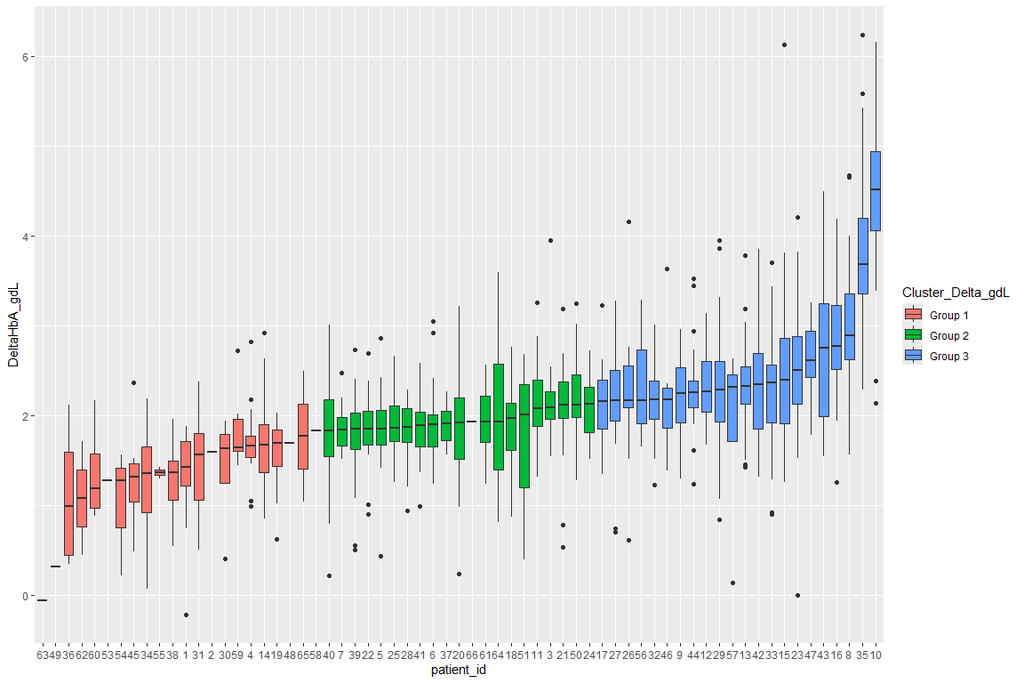

### 3 Grupos

| Tercil with Delta gdL | Group 1 N = 221 | Group 2 N = 211 | Group 3 N = 221 | p-value2 |
| --- | --- | --- | --- | --- |
| RBC antibodies |  |  |  | 0.36 |
| No | 14 (64%) | 9 (43%) | 13 (59%) |  |
| Yes | 8 (36%) | 12 (57%) | 9 (41%) |  |
| Age |  |  |  | 0.001 |
| Mean (SD) | 36 (12) | 31 (11) | 23 (13) |  |
| Median | 35 | 31 | 22 |  |
| Min - Max | 19 - 70 | 14 - 51 | 8 - 61 |  |
| Q1 - Q3 | 26 - 40 | 22 - 38 | 11 - 24 |  |
| Height (cm) |  |  |  | 0.11 |
| Mean (SD) | 170 (10) | 169 (8) | 162 (17) |  |
| Median | 168 | 170 | 162 |  |
| Min - Max | 150 - 193 | 156 - 185 | 130 - 197 |  |
| Q1 - Q3 | 163 - 178 | 163 - 173 | 152 - 175 |  |
| Weight (kg) |  |  |  | 0.16 |
| Mean (SD) | 75 (18) | 71 (18) | 60 (20) |  |
| Median | 70 | 65 | 65 |  |
| Min - Max | 48 - 124 | 48 - 107 | 25 - 92 |  |
| Q1 - Q3 | 65 - 80 | 60 - 79 | 40 - 78 |  |
| Gender |  |  |  | 0.30 |
| Female | 14 (64%) | 10 (48%) | 9 (41%) |  |
| Male | 8 (36%) | 11 (52%) | 13 (59%) |  |
| Race |  |  |  | 0.38 |
| Black | 22 (100%) | 20 (95%) | 19 (86%) |  |
| other | 0 (0%) | 1 (4.8%) | 2 (9.1%) |  |
| White | 0 (0%) | 0 (0%) | 1 (4.5%) |  |
| SCD Genotype |  |  |  | 0.002 |
| Group 1 - SS/SBO thal | 16 (73%) | 21 (100%) | 22 (100%) |  |
| Group 2 - SC/sickle cell beta plus thalassemia | 4 (18%) | 0 (0%) | 0 (0%) |  |
| Other | 2 (9.1%) | 0 (0%) | 0 (0%) |  |
| Splenectomy (%) |  |  |  | 0.089 |
| No | 21 (95%) | 15 (71%) | 17 (77%) |  |
| Yes | 1 (4.5%) | 6 (29%) | 5 (23%) |  |
| Splenomegaly or Hepatomegaly (%) |  |  |  | 0.79 |
| no | 15 (68%) | 15 (71%) | 17 (77%) |  |
| yes | 7 (32%) | 6 (29%) | 5 (23%) |  |
| abo_group_11 |  |  |  | 0.85 |
| A | 3 (14%) | 5 (24%) | 2 (9.1%) |  |
| AB | 2 (9.1%) | 2 (9.5%) | 1 (4.5%) |  |
| B | 4 (18%) | 4 (19%) | 4 (18%) |  |
| O | 13 (59%) | 10 (48%) | 15 (68%) |  |
| ABO Group |  |  |  | 0.56 |
| G:A - D pos | 3 (14%) | 5 (24%) | 2 (9.1%) |  |
| G:AB - D pos | 2 (9.1%) | 2 (9.5%) | 1 (4.5%) |  |
| G:B - D pos | 4 (18%) | 4 (19%) | 4 (18%) |  |
| G:O - D neg | 0 (0%) | 2 (9.5%) | 0 (0%) |  |
| G:O - D pos | 13 (59%) | 8 (38%) | 15 (68%) |  |

1n (%)  
2Pearson's Chi-squared test; Kruskal-Wallis rank sum test; Fisher's exact test

| RBC antibodies | Group 1 N = 22 | Group 2 N = 21 | Group 3 N = 22 | p-value1 |
| --- | --- | --- | --- | --- |
| Mean Age of Unit by Patient |  |  |  | 0.81 |
| Mean (SD) | 17.4 (4.8) | 17.7 (2.8) | 17.4 (3.7) |  |
| Median | 18.0 | 18.4 | 17.0 |  |
| Min - Max | 8.2 - 26.4 | 12.6 - 22.8 | 11.9 - 27.4 |  |
| Q1 - Q3 | 12.7 - 20.1 | 15.5 - 19.8 | 15.3 - 19.2 |  |

1Kruskal-Wallis rank sum test

| Characteristic | Group 1 N = 22 | Group 2 N = 21 | Group 3 N = 22 | p-value1 |
| --- | --- | --- | --- | --- |
| Count ED Coding by Patient |  |  |  | 0.69 |
| Mean (SD) | 9 (15) | 5 (11) | 4 (9) |  |
| Median | 3 | 2 | 2 |  |
| Min - Max | 0 - 59 | 0 - 52 | 0 - 45 |  |
| Q1 - Q3 | 0 - 15 | 0 - 6 | 1 - 4 |  |

1Kruskal-Wallis rank sum test

| Names | Code_Names | Estimation.mean.least.Cluster_Delta_gdL | Estimation.mean.least.emmean | Estimation.mean.least.SE | p.value |
| --- | --- | --- | --- | --- | --- |
| Pre A % | pre_a_percent | Group 1 | 42.08788 | 2.843843 | 0.008506538 |
|  |  | Group 2 | 52.83469 | 2.711472 |  |
|  |  | Group 3 | 56.90433 | 2.622299 |  |

| Names | Code_Names | Estimation.mean.least.Cluster_Delta_gdL | Estimation.mean.least.emmean | Estimation.mean.least.SE | p.value |
| --- | --- | --- | --- | --- | --- |
| Post A % | post_a_percent | Group 1 | 71.35564 | 2.084171 | 0.01437712 |
|  |  | Group 2 | 78.79096 | 2.060094 |  |
|  |  | Group 3 | 82.23313 | 2.002166 |  |

| Names | Code_Names | Estimation.mean.least.Cluster_Delta_gdL | Estimation.mean.least.emmean | Estimation.mean.least.SE | p.value |
| --- | --- | --- | --- | --- | --- |
| Goal/Target Post-RCE HCT (%) | goal_target_post_rce_hct_percent | Group 1 | 27.72315 | 0.6029346 | 0.3910904 |
|  |  | Group 2 | 28.45454 | 0.5948521 |  |
|  |  | Group 3 | 29.28199 | 0.5779706 |  |

| Names | Code_Names | Estimation.mean.least.Cluster_Delta_gdL | Estimation.mean.least.emmean | Estimation.mean.least.SE | p.value |
| --- | --- | --- | --- | --- | --- |
| Goal/Target Post-RCE HbS (%) | goal_target_post_rce_hb_s_percent | Group 1 | 27.52001 | 1.365693 | 0.00165367 |
|  |  | Group 2 | 21.22816 | 1.340884 |  |
|  |  | Group 3 | 19.08908 | 1.306064 |  |

| Names | Code_Names | Estimation.mean.least.Cluster_Delta_gdL | Estimation.mean.least.emmean | Estimation.mean.least.SE | p.value |
| --- | --- | --- | --- | --- | --- |
| Pre-RCE HbS (%) | pre_rce_hb_s_percent | Group 1 | 46.7932 | 2.603475 | 0.4967088 |
|  |  | Group 2 | 44.3368 | 2.474768 |  |
|  |  | Group 3 | 39.8579 | 2.392434 |  |

| Names | Code_Names | Estimation.mean.least.Cluster_Delta_gdL | Estimation.mean.least.emmean | Estimation.mean.least.SE | p.value |
| --- | --- | --- | --- | --- | --- |
| Post-RCE HbS (%) | post_rce_hb_s_percent | Group 1 | 21.22100 | 1.271767 | 0.2675513 |
|  |  | Group 2 | 19.25539 | 1.213090 |  |
|  |  | Group 3 | 15.74205 | 1.173260 |  |

| Names | Code_Names | Estimation.mean.least.Cluster_Delta_gdL | Estimation.mean.least.emmean | Estimation.mean.least.SE | p.value |
| --- | --- | --- | --- | --- | --- |
| difference between procedure times | DIFF_Between_RCE | Group 1 | 58.67441 | 7.181716 | 0.1720981 |
|  |  | Group 2 | 45.58679 | 6.114303 |  |
|  |  | Group 3 | 36.39793 | 5.823625 |  |

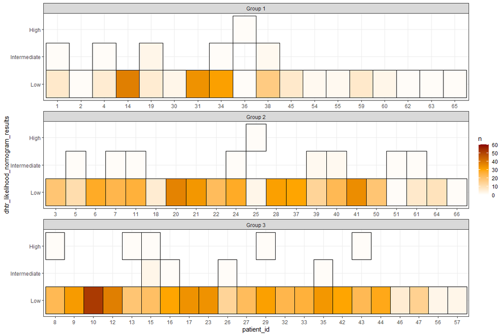

| Characteristic | Group 1 N = 2071 | Group 2 N = 4431 | Group 3 N = 5711 | p-value2 |
| --- | --- | --- | --- | --- |
| dhtr_likelihood_nomogram_results |  |  |  | 0.038 |
| Low | 168 (95%) | 407 (97%) | 542 (98%) |  |
| High | 1 (0.6%) | 1 (0.2%) | 5 (0.9%) |  |
| Intermediate | 8 (4.5%) | 10 (2.4%) | 6 (1.1%) |  |
| Unknown | 30 | 25 | 18 |  |

1n (%)  
2Fisher's Exact Test for Count Data with simulated p-value (based on 2000 replicates)

### 2 Grupos

| Tercil with Delta gdL | Group 1 N = 221 | Group 3 N = 221 | p-value2 |
| --- | --- | --- | --- |
| RBC antibodies |  |  | 0.76 |
| No | 14 (64%) | 13 (59%) |  |
| Yes | 8 (36%) | 9 (41%) |  |
| Age |  |  | <0.001 |
| Mean (SD) | 36 (12) | 23 (13) |  |
| Median | 35 | 22 |  |
| Min - Max | 19 - 70 | 8 - 61 |  |
| Q1 - Q3 | 26 - 40 | 11 - 24 |  |
| Height (cm) |  |  | 0.069 |
| Mean (SD) | 170 (10) | 162 (17) |  |
| Median | 168 | 162 |  |
| Min - Max | 150 - 193 | 130 - 197 |  |
| Q1 - Q3 | 163 - 178 | 152 - 175 |  |
| Weight (kg) |  |  | 0.074 |
| Mean (SD) | 75 (18) | 60 (20) |  |
| Median | 70 | 65 |  |
| Min - Max | 48 - 124 | 25 - 92 |  |
| Q1 - Q3 | 65 - 80 | 40 - 78 |  |
| Gender |  |  | 0.13 |
| Female | 14 (64%) | 9 (41%) |  |
| Male | 8 (36%) | 13 (59%) |  |
| Race |  |  | 0.23 |
| Black | 22 (100%) | 19 (86%) |  |
| other | 0 (0%) | 2 (9.1%) |  |
| White | 0 (0%) | 1 (4.5%) |  |
| SCD Genotype |  |  | 0.021 |
| Group 1 - SS/SBO thal | 16 (73%) | 22 (100%) |  |
| Group 2 - SC/sickle cell beta plus thalassemia | 4 (18%) | 0 (0%) |  |
| Other | 2 (9.1%) | 0 (0%) |  |
| Splenectomy (%) |  |  | 0.19 |
| No | 21 (95%) | 17 (77%) |  |
| Yes | 1 (4.5%) | 5 (23%) |  |
| Splenomegaly or Hepatomegaly (%) |  |  | 0.50 |
| no | 15 (68%) | 17 (77%) |  |
| yes | 7 (32%) | 5 (23%) |  |
| abo_group_11 |  |  | 0.92 |
| A | 3 (14%) | 2 (9.1%) |  |
| AB | 2 (9.1%) | 1 (4.5%) |  |
| B | 4 (18%) | 4 (18%) |  |
| O | 13 (59%) | 15 (68%) |  |
| ABO Group |  |  | 0.92 |
| G:A - D pos | 3 (14%) | 2 (9.1%) |  |
| G:AB - D pos | 2 (9.1%) | 1 (4.5%) |  |
| G:B - D pos | 4 (18%) | 4 (18%) |  |
| G:O - D pos | 13 (59%) | 15 (68%) |  |

1n (%)  
2Pearson's Chi-squared test; Wilcoxon rank sum test; Fisher's exact test

| RBC antibodies | Group 1 N = 22 | Group 3 N = 22 | p-value1 |
| --- | --- | --- | --- |
| Mean Age of Unit by Patient |  |  | 0.83 |
| Mean (SD) | 17.4 (4.8) | 17.4 (3.7) |  |
| Median | 18.0 | 17.0 |  |
| Min - Max | 8.2 - 26.4 | 11.9 - 27.4 |  |
| Q1 - Q3 | 12.7 - 20.1 | 15.3 - 19.2 |  |

1Wilcoxon rank sum exact test

| Characteristic | Group 1 N = 22 | Group 3 N = 22 | p-value1 |
| --- | --- | --- | --- |
| Count ED Coding by Patient |  |  | 0.49 |
| Mean (SD) | 9 (15) | 4 (9) |  |
| Median | 3 | 2 |  |
| Min - Max | 0 - 59 | 0 - 45 |  |
| Q1 - Q3 | 0 - 15 | 1 - 4 |  |

1Wilcoxon rank sum test

[1] “pre_a_percent”

| Names | Code_Names | Estimation.mean.least.Cluster_Delta_gdL | Estimation.mean.least.emmean | Estimation.mean.least.SE | p.value |
| --- | --- | --- | --- | --- | --- |
| Pre A % | pre_a_percent | Group 1 | 41.92714 | 2.545905 | 0.00008722472 |
|  |  | Group 3 | 57.31556 | 2.377510 |  |

[1] “post_a_percent”

| Names | Code_Names | Estimation.mean.least.Cluster_Delta_gdL | Estimation.mean.least.emmean | Estimation.mean.least.SE | p.value |
| --- | --- | --- | --- | --- | --- |
| Post A % | post_a_percent | Group 1 | 70.38747 | 2.472539 | 0.001620623 |
|  |  | Group 3 | 82.15259 | 2.425027 |  |

[1] “goal_target_post_rce_hct_percent”

| Names | Code_Names | Estimation.mean.least.Cluster_Delta_gdL | Estimation.mean.least.emmean | Estimation.mean.least.SE | p.value |
| --- | --- | --- | --- | --- | --- |
| Goal/Target Post-RCE HCT (%) | goal_target_post_rce_hct_percent | Group 1 | 27.77463 | 0.5185474 | 0.04800603 |
|  |  | Group 3 | 29.24742 | 0.5036613 |  |

[1] “goal_target_post_rce_hb_s_percent”

| Names | Code_Names | Estimation.mean.least.Cluster_Delta_gdL | Estimation.mean.least.emmean | Estimation.mean.least.SE | p.value |
| --- | --- | --- | --- | --- | --- |
| Goal/Target Post-RCE HbS (%) | goal_target_post_rce_hb_s_percent | Group 1 | 27.36008 | 1.351212 | 0.00007107634 |
|  |  | Group 3 | 19.02919 | 1.329645 |  |

[1] “pre_rce_hb_s_percent”

| Names | Code_Names | Estimation.mean.least.Cluster_Delta_gdL | Estimation.mean.least.emmean | Estimation.mean.least.SE | p.value |
| --- | --- | --- | --- | --- | --- |
| Pre-RCE HbS (%) | pre_rce_hb_s_percent | Group 1 | 46.86830 | 2.391142 | 0.02983803 |
|  |  | Group 3 | 39.50182 | 2.235967 |  |

[1] “post_rce_hb_s_percent”

| Names | Code_Names | Estimation.mean.least.Cluster_Delta_gdL | Estimation.mean.least.emmean | Estimation.mean.least.SE | p.value |
| --- | --- | --- | --- | --- | --- |
| Post-RCE HbS (%) | post_rce_hb_s_percent | Group 1 | 21.58599 | 1.227371 | 0.001309661 |
|  |  | Group 3 | 15.76470 | 1.158334 |  |

[1] “DIFF_Between_RCE”

| Names | Code_Names | Estimation.mean.least.Cluster_Delta_gdL | Estimation.mean.least.emmean | Estimation.mean.least.SE | p.value |
| --- | --- | --- | --- | --- | --- |
| difference between procedure times | DIFF_Between_RCE | Group 1 | 80.87537 | 13.56944 | 0.02285671 |
|  |  | Group 3 | 35.77397 | 13.20206 |  |

[output not shown]

1n (%)  
2Fisher's Exact Test for Count Data with simulated p-value (based on 2000 replicates)

[^1]: wyhirai@gmail.com